# Perception and Participation

*An analysis of immigration media coverage's impact on labor force participation*

## Focus: Reality vs. Economic Theory in Immigration Impact on Labor Force Participation

## Key Question

Does media coverage drive deviations from economic theory?

## Importance of Study

**Significance:** Understanding the link between immigration, media, and native-born labor force participation

**Rationale:** Crucial amidst polarized rhetoric and alarming changes in labor force participation

## Paper's Objective

**Analyze Combinations:**

- Various immigration types (e.g., high-skill substitutions)
- Media publications during the same period

**Understand the correlations between the two variables**

## Methodolgy

**Combination Analysis:**

- Immigration types
- Media publications

## Key Findings

We fail to find statistical significance between the relationship of the variables.

While there is potential for this relationship to exist based on the present literature, these results are not statistically significant when scaled to a larger population.

## Contributions to Discussions

**Purpose:** Facilitate more nuanced discussions on immigration

**Goal:** Inform public discourse with evidence-based insights

# Q&A

## Introduction

Recently, immigration policy has fueled contentious debates, particularly concerning its impact on native-born individuals. Amidst extensive media coverage, many narratives have emerged.

This paper focuses on media coverage surrounding immigration policy to note if any changes in labor participation, or deviation from economic theory, can be directly correlated to media coverage. Leveraging AI-powered systems, narratives surrounding immigration will be analyzed. Instead of researching individual news sources, Google Trends will be used for data collection to help track crowd interest and sentiment. With this data collection strategy, misinformation and core publications will be represented but through an additional variable, core publications will have a heavier weight. This weighting is necessary for core publications tend to have more public trust and a higher likelihood of programs and policies being influenced by these reports.

The methodology to track the economic impacts media has on labor force participation is to establish predictions based on economic theory as a baseline. From this baseline, real-world findings will be mapped on the same axes to show the magnitude of deviation. Periods with deviation will be noted and the media coverage during the same period will analyzed to note its potential influence. By recognizing the correlation between these two variables, a conclusion can be made regarding the potential relationship between media and labor force participation.

Current literature will be referenced to offer context and a backdrop for the paper's findings within the academic world. The core difference between the predicted findings of this paper and the current literature is that this paper aims to understand the potential drivers of change in labor force participation when immigration takes place.

To ensure nuances of immigration policy are represented, the four immigration types will be analyzed: immigrants are high-skilled complements, immigrants are low-skilled complements, immigrants are high-skilled substitutes, and immigrants are low-skilled substitutes. An example of a high-skill substitute may be immigrants who are brought to work within innovative sectors like the technology sector. In direct contrast, an example of a low-skilled substitute may be someone working a job in construction.

These findings will contribute to more nuanced discussions on immigration by highlighting the diversity among immigrant types, their economic impacts, and the impact of media coverage. In summary, by highlighting the diversity among immigrant types, their economic impacts, and the influence of media coverage this paper aims to understand the drivers behind deviations from labor economic models regarding immigration.

## Literature Review

### Immigration's Economic Impacts

#### 1. Altering of Wages in the Short Run

#### 1. Altering of Wages in the Short Run

Based on economic theory, an influx of immigrants should result in an increase in labor supply and as a consequence a decrease in wages in the short run.

Within literature it is recognized that immigration does not affect attrition, nor the probabilities of native-born workers finding a job, but it is associated with smaller probabilities of remaining unemployed{cite:p}`Rios-Avila2020-ga`. It is also noted that there is a small risk of unemployed native-born citizens leaving the labor force if they live in a state with a significantly positive net flow of immigrants{cite:p}`Rios-Avila2020-ga`. This risk is mainly due to the employment and wage pressure that may come from supplementary immigration.

If an immigrant is supplementary, or can easily replace a native-born worker in that field, individuals will witness a decrease in pay due to an increase in labor supplied. Conversely, if an immigrant is complementary, or works alongside a native-born worker in a different field, there will still be an increase in labor supplied and the expected wage decrease for the immigrants, but a wage increase for workers in the complementary industry. This wage increase is due to changes in a company's wage and capital allocation which will spur an increase in labor demanded for complementary work thus increasing the wages of these workers.

Based on the narrative spread by the media, this paper asserts that individuals may be more or less inclined to leave the labor force based on their wage and employment prospects.

While current literature does not take the media into effect, there exists a case study to highlight how an influx of immigration may alter labor supply and demand: the case study of the Mariel Boatlift.

##### Mariel Boatlift

Despite the large influx of immigrants, there was no indication that the Boatlift led to an increase in the unemployment rates of less-skilled blacks or other non-Cuban workers{cite:p}`Card1990-au`. This paper also highlighted that Miami was better acclimated to support an influx of immigrants ––especially Hispanic immigrants{cite:p}`Card1990-au`. This is due to their economy having a large number of complementary jobs to low-skill labor which aided in job mobility of native-born workers instead of unemployment. Furthermore due to core factors, like a lower language barrier, the assimilation of immigrants was high which led to a more productive market that increased the labor demand potentially offsetting any wage decreases in many jobs.

It should be noted that while virtually no effect on the wages of non-Cuban workers, it is believed that a part of the impact was mitigated by the second economic impact of immigration: internal migration {cite:p}`Card1990-au`.

### Immigration's Economic Impacts

#### 2. Internal Migration of Workers

#### 2. Internal Migration of Workers

As highlighted by {cite:t}`Card1990-au`, the influx of immigrants from the boatlift led to some internal emigration of native-born Americans and potentially discouraged immigration of some other immigrants. This migration aids in explaining why on a national level substantial wage effects are seen yet on a state level there are negligible impacts {cite:p}`Borjas2021-xq`. The logic highlighted in this piece of literature is that the scope of the labor market is a core determinant of the impact. Seeing that the labor market is dynamic and –– when all other variables are held equal –– individuals can move between markets, the state-level analysis may see no net effect due to emigration and immigration canceling each other. On a national level, the main effect witnessed is due to immigration since emigration from the nation is usually lower.

The findings of this paper assert that media will be a core driver of whether or not internal migration will take place. This is because the narratives promoted in the media will help shape the reasoning for individual reactions{cite:p}`Hainmueller2014-he`.

This internal migration may lead to some states witnessing differing wage and employment pressures thus leading to the final main impact of immigration: altering labor force participation.

### Immigration's Economic Impacts

#### 3. Altering Labor Force Participation

#### 3. Altering Labor Force Participation

While the current literature already highlighted some ways to mitigate wage changes, another core way that this may happen is that the labor supply decreases as individuals fail to participate in the labor force. This may happen for two main reasons: individuals leave in order to attain higher education and consequently higher pay, or individuals become discouraged.

##### Exiting Labor Force to Gain Higher Education

This notion was partially highlighted in the analysis of the Mariel Boatlift by {cite:t}`Card1990-au`. As Card notes, some individuals underwent training to attain higher paying jobs or managerial positions which offered positions for immigrants to fill without decreasing the wage{cite:p}`Card1990-au`. While these individuals may not have left the workforce, it is not uncommon for individuals to attain a higher education seeing that there has been a predicted wage decrease or increase in employment pressures.

##### Discouragement of Workers

The discouraged worker effect –– as described by Ríos-Avila –– is caused by the expectation that immigration will lower wages and decrease job availability {cite:p}`RiosAvila2016-ja`. This paper delves deeper into potential catalysts for this effect and champions that the media's influence on public attitudes directly influences the extent of worker discouragement.

Additionally, the findings can be used to decrease the bias that is caused by the population's current media exposure. To understand how this paper can achieve this, the literature surrounding media and perception must be analyzed.

### The Media's Impact on Perception

Current literature recognizes the ability of media to influence the views of the public especially when an ethnic threat is created {cite:p}`Mohamed2020-hr`. This paper argues that this threat creation directly translates to negative immigration views which can evolve into potential discouragement within the workforce.

A core study to strengthen this link was done of Germany by {cite:t}`Benesch2019-zs` who found that "the amount of media reports regarding migration issues is positively associated with concerns about immigration among the German population. This association is strongest when immigrants are the protagonists of media reports."{cite:p}`Benesch2019-zs`.

While an increased interest can lead to an increase in exposure, {cite:t}`Djourelova2023-dx` notes that the language used in media can support the creation of less moderate stances. {cite:t}`Mohamed2020-hr` stresses within their literary findings that tangible impacts can be seen from the media, and {cite:t}`Sadler2021-wh` quantifies this through their analysis of immigration-related reports.

This paper will remain rooted in the logic presented by these literary findings in the hopes of painting a combined perspective regarding immigration media coverage and its impact on labor force participation.

## Methodology

The core hypothesis of this paper is that deviations from economic theory will align with moments where media coverage surrounding immigration was predominantly negative. These deviations will nearly equivocally be present within the calculated labor force participation rate due to the discouraged worker effect {cite:p}`RiosAvila2016-ja`. This prediction was made under the current notion that media narratives can heavily influence public sentiment {cite:p}`Djourelova2023-dx`. This hypothesis extends this notion to highlight that media can transitively also influence labor market dynamics.

The methodology to track the aforementioned correlation is to establish predictions based on economic theory as a baseline. Drawing from immigration data, the number and skill set of immigrants will be logged. Based on this dataset, predictions will be made based on economic theory. For example, if there is a majority of complementary low-skill workers theory predicts more labor participation in high-skill work.

From these predictions, real-world findings will be mapped on the same axes to show the magnitude of deviation. The National Science Foundation will be utilized to estimate the types of work being done by laborers and the percent change over the years.

Periods with deviation will be noted and public sentiment will be gauged based on data gathered by Google Trends. Positive sentiment is based on the number of pro-immigration searches cataloged while the inverse is true for negative sentiment.

To minimize bias or error, an average will be taken of multiple variations of positive or negative indicators. For example, if the average of five samples is a negative number, then the public's sentiment was negative during that period.

Control variables may not be directly used due to media and the social impacts existing in some form regardless of media type. To see how much change in labor participation is due to media perception, the paper will look at the historical cases of large influxes of immigration and labor force participation changes. Any increase in magnitude could be attributed to modern media's influences on individual concerns.

By recognizing the correlation between these two variables, a conclusion can be made regarding the potential relationship between media and labor force participation. OLS regression analysis will be utilized as the main statistical model.

Additionally, current literature regarding media's influence on immigration views is centered around 2009 to 2020 due to stark political views presented by former President Obama and former President Trump{cite:p}`Sadler2021-wh`. The findings of this paper will be visualized to take GOP presidencies into account while also highlighting core immigration policy changes and changes in economic conditions.

This methodology highlighted will ensure that a proper relationship can be tracked between the media and changes in labor force participation. With causality proven through previous literature, these findings can be used to avoid the negative implications of immigration on labor force participation.

## Findings

### Analyzing the trends presented through Google Trends Data

#### Gauging Public Sentiment

By tracking searches of pro-immigration versus anti-immigration on Google Trends the following graph was compiled. On average the variation between pro-immigration and anti-immigration is pretty split but the magnitude varies the most greatly during election years. The core outlier of this is 2018 due to an increased amount of rhetoric in both the political and news landscapes.

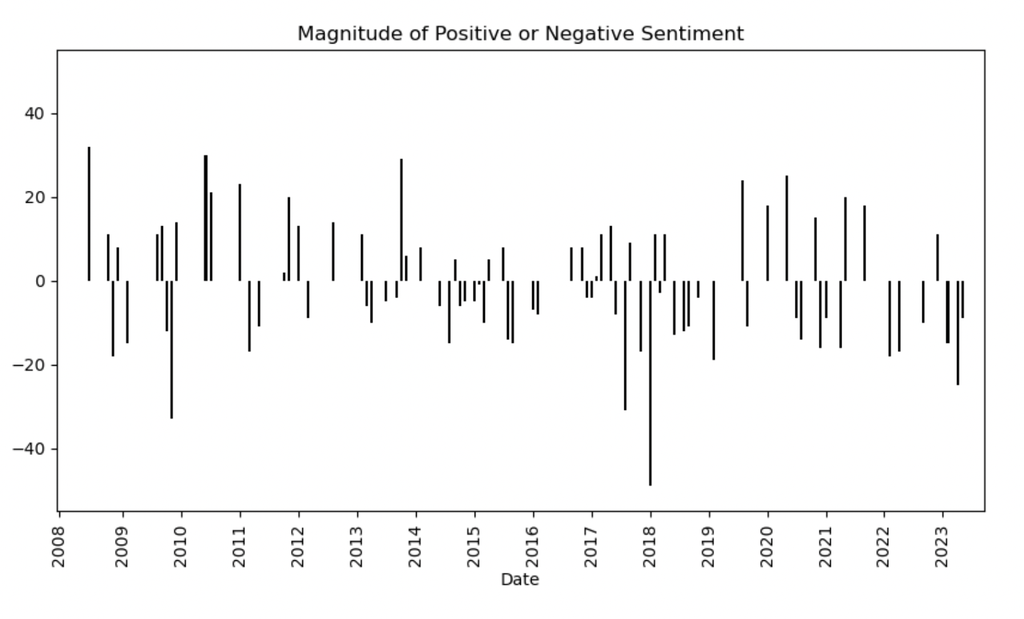

#### Gauging Public Interest in Immigration Policy

To further assess this claim, public interest in immigration policy was also tracked, and a similar trend in magnitude was witnessed.

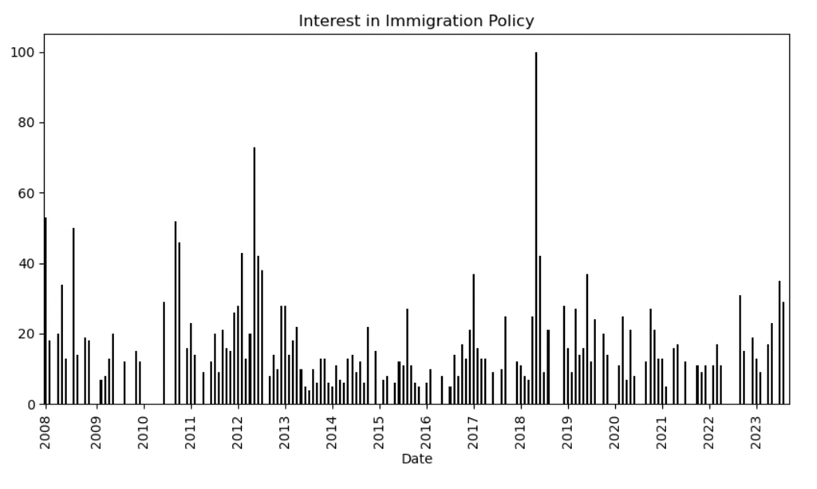

#### Contextualizing Trends in Terms of Potential Political Influence

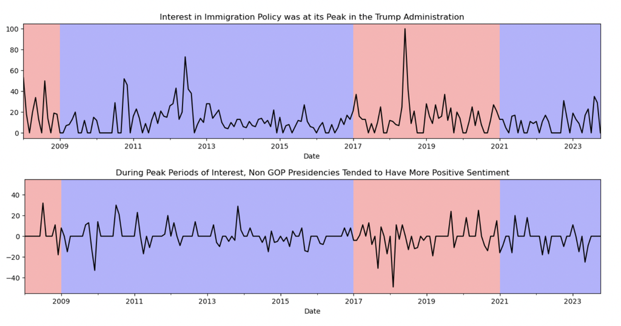

## Results

The R-squared and adjusted R-squared values are 0.002 and -0.009 respectively. Recognizing that the fit of the model is not as high does not diminish the correlations highlighted above. With a more dense data set and API access, one could better gauge the impact to see the core influence. Previous highlighted literature showcases that having the ability to see change on a micro level helps amplify the change and it is encouraged for future research to consider this in their efforts.

Within the presence of multicollinearity, our findings and analysis suggest that imperfect multicollinearity may be present but perfect multicollinearity is not.

Within the data set, there was one core influential observation witnessed in 2018. Due to an increased amount of rhetoric, coverage, and overall exposure of immigration policy and trends, we see that any effects were magnified. This is especially highlighted in the third graph presented within the findings. With our current data set, we cannot state that the coefficients are statistically significant at a significance level of 5%. The failure to reject the hypothesis that there is no casual effect can mainly be attributed to the data set and not the trend itself.

The model fit being poor explains the lack of variation and hinders the model's ability to provide meaningful insights into the economic relationships being studied. Furthermore, with a more diverse and large dataset, robustness checks alongside sensitivity analyses could be conducted to assess the validity of the results. This paper acknowledges the limitations of resources for API visibility but encourages those with the proper resources to build on these findings.

### OLS Summary

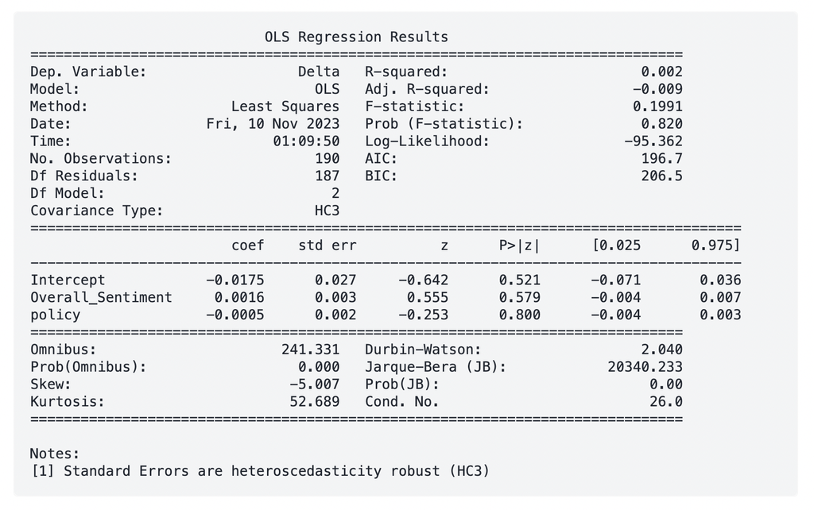

## Conclusion

The author of this paper urges future researchers, especially those with access to more dense APIs, to track the impact of media on public perception to then tie it into its connection with changes in labor force participation. In the meantime, the author encourages for the current correlation of influence to be considered when structuring conversations surrounding immigration and its impact on the labor market.